# Market Basket Analysis in Python for Grocery Dataset

## Introduction & Data Commentary

The full dataset can be found on Kaggle here: https://www.kaggle.com/datasets/irfanasrullah/groceries?select=groceries+-+groceries.csv

It is fairly basic and no strong changes need to be performed in advance; I chose to drop the '# Item(s)' column in place below but you could easily do so in Excel or another spreadsheet tool beforehand.

Our first stop is to make data transformations, preparing our data for onehot encoding, which is essentially turning it into a grid with values of "True" or "False" (or "0" or "1") representing the products. This is done in the form of transactions, as is the intent of the dataset overall.

Having data in this format allows us to explore it at length and create various visualizations to help identify rules between given pairs of grocery store items and assess them on various metrics so we can figure out which rules are most closely correlated.

As an example, this would allow you to know through data if milk and eggs were actually closely correlated or if that is simply an assumption that people make without legitimacy behind it.

In this example, we're not looking to identify or answer questions about specific pairings although we could if we wanted to. What we do instead is to seek to trim the amount of rules present in order to understand which products are closely related and therefore how they could be marketed or have their positions relative to one another improved in-store.

I won't go into great detail about each metric here as that information is available online, ubiquitously.

## Importing Packages Needed for Analysis

```python
import pandas as pd
import seaborn as sns
import numpy as np
import matplotlib.pyplot as plt
import os
from mlxtend.preprocessing import TransactionEncoder
from mlxtend.frequent_patterns import apriori, association_rules
from pandas.plotting import parallel_coordinates
```

Checking and setting active directory to avoid file issues.

```python
print(os.getcwd())
path = "F:\[Personal]\Data Analytics Portfolio\Market Basket Analysis\mba"
os.chdir(path)
print(os.getcwd())
```

```
F:\[Personal]\Data Analytics Portfolio\Market Basket Analysis\mba
F:\[Personal]\Data Analytics Portfolio\Market Basket Analysis\mba
```

## Read In Data and Initial Transformations

```python
df = pd.read_csv(r'F:\[Personal]\Data Analytics Portfolio\Market Basket Analysis\mba\groceries - groceries.csv')

# Our data has a column that we do not need for analysis so we will be dropping it altogether

df.drop(columns = df.columns[0], axis = 1, inplace = True)
```

```python
# Transforming the dataframe into a list of lists representing transactions

transactions = df.values.astype(str).tolist()

# Delete the nans in the list of lists

transactions = [[item for item in row if item != 'nan'] for row in transactions]

# Print first 5 lists to check our work

print(transactions[:5])
```

```
[['citrus fruit', 'semi-finished bread', 'margarine', 'ready soups'], ['tropical fruit', 'yogurt', 'coffee'], ['whole milk'], ['pip fruit', 'yogurt', 'cream cheese', 'meat spreads'], ['other vegetables', 'whole milk', 'condensed milk', 'long life bakery product']]
```

## Calculating the Support Metric

```python
# First, we instantiate the transition encoder which will enable us to onehot encode the data

encoder = TransactionEncoder().fit(transactions)

# Perform onehot encoding (could be chained above but calling out separately for readability)

onehot = encoder.transform(transactions)

# Convert onehot to a DataFrame

onehot = pd.DataFrame(onehot, columns = encoder.columns_)

# Check output

print(onehot)
```

```
      Instant food products  UHT-milk  abrasive cleaner  artif. sweetener  \
0                     False     False             False             False
1                     False     False             False             False
2                     False     False             False             False
3                     False     False             False             False
4                     False     False             False             False
...                     ...       ...               ...               ...
9830                  False     False             False             False
9831                  False     False             False             False
9832                  False     False             False             False
9833                  False     False             False             False
9834                  False     False             False             False

      baby cosmetics  baby food   bags  baking powder  bathroom cleaner  \
0              False      False  False          False             False
```

[output cut: 38 more lines]

```python
# Computing Support for Single Items

print(onehot.mean())
```

```
Instant food products    0.008033
UHT-milk                 0.033452
abrasive cleaner         0.003559
artif. sweetener         0.003254
baby cosmetics           0.000610
                           ...
white bread              0.042095
white wine               0.019014
whole milk               0.255516
yogurt                   0.139502
zwieback                 0.006914
Length: 169, dtype: float64
```

## Using the Aprori Algorithm

```python
frequent_itemsets = apriori(onehot, min_support = 0.001, use_colnames = True)

print(len(frequent_itemsets))
```

```
13492
```

```python
rules = association_rules(frequent_itemsets, metric = 'support', min_threshold = 0.001)
print(rules[:5])
```

```
               antecedents              consequents  antecedent support  \
0          (bottled water)  (Instant food products)            0.110524
1  (Instant food products)          (bottled water)            0.008033
2  (Instant food products)                 (butter)            0.008033
3                 (butter)  (Instant food products)            0.055414
4           (citrus fruit)  (Instant food products)            0.082766

   consequent support   support  confidence      lift  leverage  conviction
0            0.008033  0.001017    0.009200  1.145296  0.000129    1.001178
1            0.110524  0.001017    0.126582  1.145296  0.000129    1.018386
2            0.055414  0.001220    0.151899  2.741145  0.000775    1.113765
3            0.008033  0.001220    0.022018  2.741145  0.000775    1.014301
4            0.008033  0.001118    0.013514  1.682347  0.000454    1.005556
```

```python
print(frequent_itemsets.nlargest(n = 15, columns = 'support'))
```

```
      support            itemsets
154  0.255516        (whole milk)
96   0.193493  (other vegetables)
115  0.183935        (rolls/buns)
130  0.174377              (soda)
155  0.139502            (yogurt)
10   0.110524     (bottled water)
116  0.108998   (root vegetables)
147  0.104931    (tropical fruit)
125  0.098526     (shopping bags)
122  0.093950           (sausage)
99   0.088968            (pastry)
28   0.082766      (citrus fruit)
9    0.080529      (bottled beer)
89   0.079817        (newspapers)
18   0.077682       (canned beer)
```

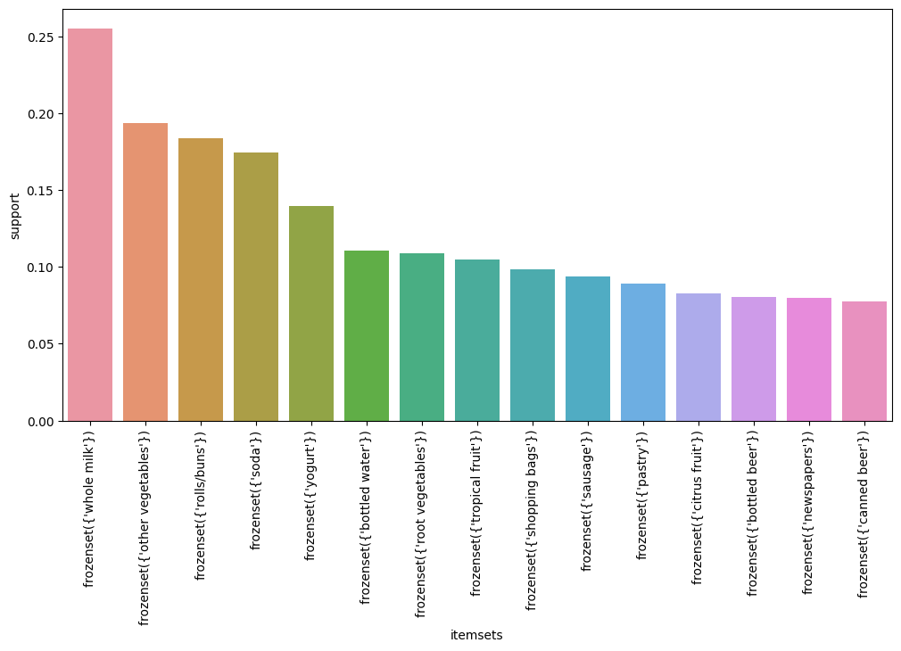

```python
plt.figure(figsize=(12,6))
plt.xticks(rotation = 90)
sns.barplot(x = 'itemsets', y = 'support', data = frequent_itemsets.nlargest(n = 15, columns = 'support'))
```

## Exploring Our Newly Made Rules

```python
print(rules.columns)
```

```
Index(['antecedents', 'consequents', 'antecedent support',
       'consequent support', 'support', 'confidence', 'lift', 'leverage',
       'conviction'],
      dtype='object')
```

```python
print(rules[['antecedents','consequents']])
```

```
                    antecedents  \
0               (bottled water)
1       (Instant food products)
2       (Instant food products)
3                      (butter)
4                (citrus fruit)
...                         ...
102761     (whipped/sour cream)
102762         (tropical fruit)
102763        (root vegetables)
102764                 (yogurt)
102765             (whole milk)

                                              consequents
0                                 (Instant food products)
1                                         (bottled water)
2                                                (butter)
3                                 (Instant food products)
4                                 (Instant food products)
...                                                   ...
102761  (other vegetables, tropical fruit, root vegeta...
102762  (other vegetables, whipped/sour cream, root ve...
102763  (other vegetables, whipped/sour cream, tropica...
102764  (other vegetables, whipped/sour cream, tropica...
102765  (other vegetables, whipped/sour cream, tropica...

[102766 rows x 2 columns]
```

## Visualization: Heatmap

Making a new frequent_itemsets and a new rules allows me to tinker with the numbers to generate a heatmap which isn't overwhelming.

Finding the right support levels to limit data to be comprehensible is more of an art than a science and can be better inferred in a business where there is domain knowledge that would inform numerical choices in analysis.

Here, the focus in on a readable visualization and to demonstrate skill and ability to extend this framework to any such analysis.

```python
frequent_itemsets2 = apriori(onehot, min_support = 0.0001, use_colnames = True, max_len = 2)
rules2 = association_rules(frequent_itemsets2)
```

```python
# Convert antecedents and consequents into strings

rules2['antecedents'] = rules2['antecedents'].apply(lambda a: ','.join(list(a)))
rules2['consequents'] = rules2['consequents'].apply(lambda a: ','.join(list(a)))

# Print to check

print(rules2[['antecedents','consequents']])
```

```
              antecedents             consequents
0               baby food             brown bread
1               baby food                  butter
2               baby food             butter milk
3               baby food                cake bar
4               baby food               chocolate
5               baby food                    curd
6               baby food                 dessert
7               baby food       finished products
8               baby food       frozen vegetables
9               baby food   fruit/vegetable juice
10              baby food        other vegetables
11              baby food                   pasta
12              baby food                  pastry
13              baby food               pip fruit
```

[output cut: 22 more lines]

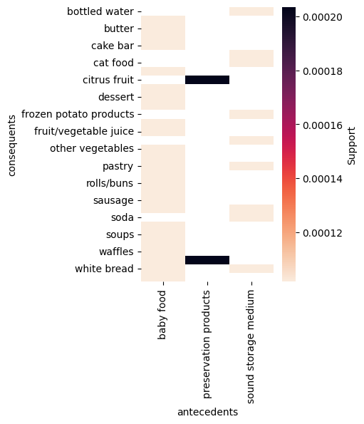

```python
# Transform the antecedent, consequent, and support columns into a matrix

support_table = rules2.pivot(index = 'consequents', columns = 'antecedents', values = 'support')

# Generate heatmap of Support

fig, ax = plt.subplots(figsize=(3, 5))
sns.heatmap(support_table, cmap = 'rocket_r', cbar_kws={'label': 'Support'})
plt.show()
```

## Visualization: Scatterplot

Scatterplots in this type of analysis allow us to identify natural thresholds in our data and we can see an entire dataset worth of rules, not just a few at a time.

The goal should be to use the findings to help us prune different rules in order to indentify the best ones.

We don't so much see individual information here but playing with the plot and values allow us to prune in a visual fashion.

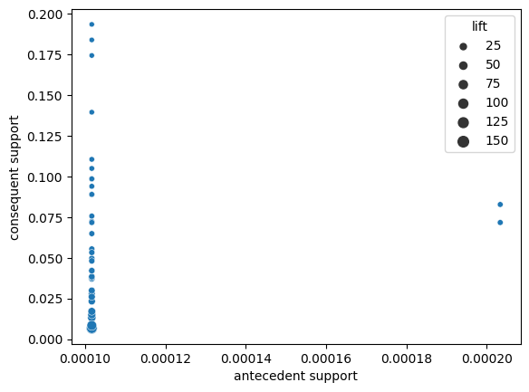

```python
sns.scatterplot(x = 'antecedent support', y = 'consequent support', size = 'lift', data = rules2)
plt.show()
```

## Visualization: Parallel Coordinates Plot

```python
# To make this plot, we must convert our rules to coordinates
# To keep things clean and separate, let's use a 3 to denote our code

frequent_itemsets3 = apriori(onehot, min_support = 0.0001, use_colnames = True, max_len = 2)
rules3 = association_rules(frequent_itemsets3)

# Extract the first item in each set and store it as a scalar value. This allows us to use coords properly next.

rules3['antecedent'] = rules3['antecedents'].apply(lambda antecedent: list(antecedent)[0])
rules3['consequent'] = rules3['consequents'].apply(lambda consequent: list(consequent)[0])

rules3['rule'] = rules3.index

# Define coordinates and label

coords = rules3[['antecedent','consequent','rule']]
```

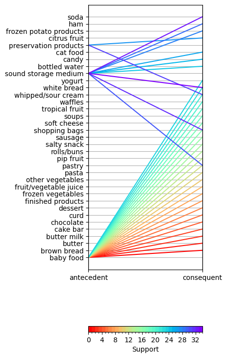

```python
# Generate the plot, indicating Support

import matplotlib as mpl

fig, ax = plt.subplots(figsize=(3, 10))
cmap = plt.get_cmap('rainbow')
rev_map = cmap.reversed()
bounds = np.arange(rules3['rule'].min(), rules3['rule'].max())
norm = mpl.colors.BoundaryNorm(bounds, 256)
parallel_coordinates(coords, 'rule', colormap = rev_map, ax = ax)
ax.legend_.remove()
plt.colorbar(mpl.cm.ScalarMappable(norm=norm, cmap=rev_map), ax=ax, orientation = 'horizontal', label='Support')
plt.show()
```

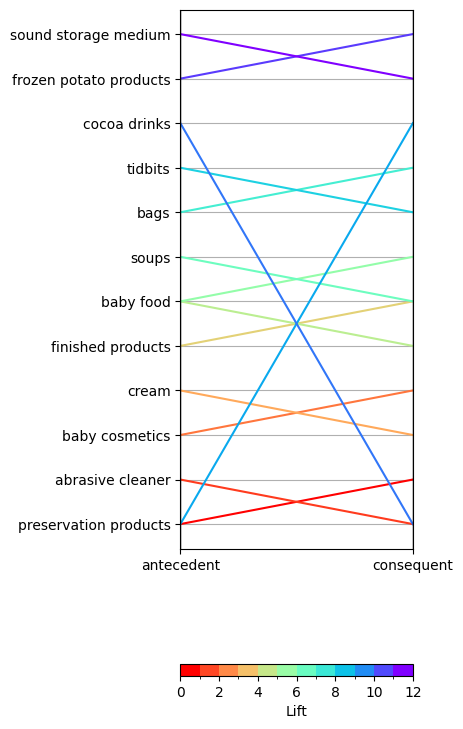

```python
# Generate the plot, indicating Lift

frequent_itemsets4 = apriori(onehot, min_support = 0.0001, use_colnames = True, max_len = 2)
rules4 = association_rules(frequent_itemsets4, metric = 'lift', min_threshold = 100)

# Extract the first item in each set and store it as a scalar value. This allows us to use coords properly next.

rules4['antecedent'] = rules4['antecedents'].apply(lambda antecedent: list(antecedent)[0])
rules4['consequent'] = rules4['consequents'].apply(lambda consequent: list(consequent)[0])

rules4['rule'] = rules4.index

# Define coordinates and label

coords = rules4[['antecedent','consequent','rule']]

import matplotlib as mpl

fig, ax = plt.subplots(figsize=(3, 10))
cmap = plt.get_cmap('rainbow')
rev_map = cmap.reversed()
bounds = np.arange(rules4['rule'].min(), rules4['rule'].max())
norm = mpl.colors.BoundaryNorm(bounds, 256)
parallel_coordinates(coords, 'rule', colormap = rev_map, ax = ax)
ax.legend_.remove()
plt.colorbar(mpl.cm.ScalarMappable(norm=norm, cmap=rev_map), ax=ax, orientation = 'horizontal', label='Lift')
plt.show()
```

Recall that Lift is the Support of **both** X and Y over the Support for X multiplied by the Support for Y.

## Results & Discussion

Generating rules and then pruning them is what you make of it; the support thresholds that you choose and narrow in on will dictate which pairings show prominently in analysis.

This is more of an art than a science because, despite narrowing down to rules with higher metrics like Support and Lift, it is ultimately on the analyst and leadership to determine where commonalities thrive in a broader sense.

In other words, we identified clear linkages between non-perishable food items, the specifics of which ones might fit together most closely indicated by analysis.

What we found through the different visualizations and exploration that we did, is that preservation products, baby food, and sound storage mediums make excellent antecedents to a variety of products as seen in the parallel coordinates plot.

Earlier on, we looked at support over all frequent items, defined by the Support metric, and found that whole milk, vegetables, bread products, and non-perishable food items were largely found within the top 15 items.

The scatterplot was a useful visualization to help pare down rules over time, although I had already been experimenting with different thresholds. Still, it was a good verification that I was able to eliminate much of the "noise" that would have been present before such pruning.

All of these findings inform us about the links between these product types and the specific products, which enables us to suggest the aforementioned pairings be advertised and placed closely together in a brick-and-mortar store.